# Which country is the best at solving Rubik's cubes?

##### An analysis by Syam Angalakuditi

## Introduction

Unless you've been living under a rock, you've probably heard of the notorious Rubik's Cube. And if you've solved it, congratulations! There's actually a massive community of "cubers" that participate in competitions for solving not only the classic 3x3 cube, but all sorts of similar puzzles, as fast as they can. These competitions are organized by the World Cube Association, also known as the WCA. Puzzles can be as small as a 2x2x2 cube, as big as a 7x7x7 cube, or even as confusing as this monstrosity, known as the Megaminx. And if solving it with your eyes open is too easy, there's also blindfolded solving. In fact, the world record for Multi-Blind solving (memorizing multiple 3x3 cubes and then solving ALL of them blindfolded) is 62/67 cubes solved correctly in under an hour!

People all over the world love to participate in these competitions. And while not every country is of equal standing, some countries are without a doubt more ahead of the game than others. So can we rank countries based on how good they are at cubing? How do we even begin to do that?

```python
#Imports
import pandas as pd
from sklearn.ensemble import RandomForestClassifier
from sklearn.model_selection import train_test_split
from sklearn.ensemble import HistGradientBoostingClassifier
from sklearn.model_selection import ShuffleSplit
import matplotlib.pyplot as plt
import statsmodels.api as sm
import seaborn as sns
import numpy as np
import statsmodels.api as sm
import folium
import pycountry
from scipy import stats
```

## 1) Data Collection

Let's gather the data. The WCA provides several CSV files, containing information encoded as needed. You can find more info on the dataset here: https://www.worldcubeassociation.org/results/misc/export.html

#### 1i) The Results table + checking for duplicates:

Let's look at the Results table. This will have information on every solve recorded at every WCA competition, for each competitor and event. Data is entered and verified by WCA officials after each competition, but just to be sure, let's check for duplicates.

```python
#Read in a large DataFrame
results_iter = pd.read_csv('data/WCA_export_Results.tsv',
                           sep='\t',
                           chunksize=50000)

df = pd.concat(results_iter)

#group by every solve to check for duplicates
group = df.groupby(['competitionId', 'personId', 'eventId', 'roundTypeId', 'best', 'average', 'value1', 'value2', 'value3', 'value4', 'value5']).count()

print("Number of rows:", len(df))
print("Number of (non-duplicate) rows:", len(group))

df
```

```
Number of rows: 3170436
Number of (non-duplicate) rows: 3170436
```

|  | competitionId | eventId | roundTypeId | pos | best | average | personName | personId | personCountryId | formatId | value1 | value2 | value3 | value4 | value5 | regionalSingleRecord | regionalAverageRecord |
| --- | --- | --- | --- | --- | --- | --- | --- | --- | --- | --- | --- | --- | --- | --- | --- | --- | --- |
| 0 | LyonOpen2007 | 333 | 1 | 15 | 1968 | 2128 | Etienne Amany | 2007AMAN01 | Cote d_Ivoire | a | 1968 | 2203 | 2138 | 2139 | 2108 | AfR | AfR |
| 1 | LyonOpen2007 | 333 | 1 | 16 | 1731 | 2140 | Thomas Rouault | 2004ROUA01 | France | a | 2222 | 2153 | 1731 | 2334 | 2046 | NaN | NaN |
| 2 | LyonOpen2007 | 333 | 1 | 17 | 2305 | 2637 | Antoine Simon-Chautemps | 2005SIMO01 | France | a | 3430 | 2581 | 2540 | 2789 | 2305 | NaN | NaN |
| 3 | LyonOpen2007 | 333 | 1 | 18 | 2452 | 2637 | Irène Mallordy | 2007MALL01 | France | a | 2715 | 2452 | 2868 | 2632 | 2564 | NaN | NaN |
| 4 | LyonOpen2007 | 333 | 1 | 19 | 2677 | 2906 | Marlène Desmaisons | 2007DESM01 | France | a | 2921 | 3184 | 2891 | 2677 | 2907 | NaN | NaN |
| ... | ... | ... | ... | ... | ... | ... | ... | ... | ... | ... | ... | ... | ... | ... | ... | ... | ... |
| 3170431 | RockyTop2022 | sq1 | f | 10 | 1111 | 1724 | Matthew Remington | 2019REMI02 | USA | a | 1722 | 1765 | 1111 | 1685 | 1799 | NaN | NaN |
| 3170432 | RockyTop2022 | sq1 | f | 4 | 1131 | 1369 | Vishwa Sankar | 2017SANK04 | USA | a | 1196 | 1695 | 1131 | 2055 | 1216 | NaN | NaN |
| 3170433 | RockyTop2022 | sq1 | f | 3 | 1192 | 1348 | Kate Grahame | 2018GRAH05 | USA | a | 1293 | 1446 | 1306 | -1 | 1192 | NaN | NaN |
| 3170434 | RockyTop2022 | sq1 | f | 9 | 1195 | 1665 | Weston Todd | 2022TODD02 | USA | a | 1807 | 1895 | 1195 | 1557 | 1631 | NaN | NaN |
| 3170435 | RockyTop2022 | sq1 | f | 11 | 1269 | 1877 | Alex Bohac | 2018BOHA01 | USA | a | 2377 | 1982 | 1273 | 2677 | 1269 | NaN | NaN |

3170436 rows × 17 columns

#### 1ii) Location Data

If we want to visualize this data on a world map, we need to be more specific than just a loosely defined country ID. Let's use the Countries and Continents tables to match the country ID present in the Results table to a standardized country code. This is known as the ISO-3166 Alpha-2 Country code, or ISO-2 for short.

```python
#Load data into pandas DF
countries = pd.read_csv('data/WCA_export_Countries.tsv', sep='\t')
conts = pd.read_csv('data/WCA_export_Continents.tsv', sep='\t')

#Merge rows with same continent id and drop extraneous rows
countries = countries.merge(conts, how='inner', left_on='continentId', right_on='id', suffixes=('_country', '_cont'))
countries.drop(columns=['id_cont', 'latitude', 'longitude'], inplace=True)

countries
```

|  | id_country | name_country | continentId | iso2 | name_cont | recordName | zoom |
| --- | --- | --- | --- | --- | --- | --- | --- |
| 0 | Afghanistan | Afghanistan | _Asia | AF | Asia | AsR | 2 |
| 1 | Bahrain | Bahrain | _Asia | BH | Asia | AsR | 2 |
| 2 | Bangladesh | Bangladesh | _Asia | BD | Asia | AsR | 2 |
| 3 | Bhutan | Bhutan | _Asia | BT | Asia | AsR | 2 |
| 4 | Brunei | Brunei | _Asia | BN | Asia | AsR | 2 |
| ... | ... | ... | ... | ... | ... | ... | ... |
| 202 | Tuvalu | Tuvalu | _Oceania | TV | Oceania | OcR | 3 |
| 203 | Vanuatu | Vanuatu | _Oceania | VU | Oceania | OcR | 3 |
| 204 | XO | Multiple Countries (Oceania) | _Oceania | XO | Oceania | OcR | 3 |
| 205 | XM | Multiple Countries (Americas) | _Multiple Continents | XM | Multiple Continents | NaN | 1 |
| 206 | XW | Multiple Countries (World) | _Multiple Continents | XW | Multiple Continents | NaN | 1 |

207 rows × 7 columns

Now we will merge the country and continent data we need with our original DataFrame.

```python
#Merge only the relevant information with Results table
df = df.merge(countries[['id_country', 'iso2', 'continentId', 'recordName']], how='inner', left_on='personCountryId', right_on='id_country')
df
```

|  | competitionId | eventId | roundTypeId | pos | best | average | personName | personId | personCountryId | formatId | ... | value2 | value3 | value4 | value5 | regionalSingleRecord | regionalAverageRecord | id_country | iso2 | continentId | recordName |
| --- | --- | --- | --- | --- | --- | --- | --- | --- | --- | --- | --- | --- | --- | --- | --- | --- | --- | --- | --- | --- | --- |
| 0 | LyonOpen2007 | 333 | 1 | 15 | 1968 | 2128 | Etienne Amany | 2007AMAN01 | Cote d_Ivoire | a | ... | 2203 | 2138 | 2139 | 2108 | AfR | AfR | Cote d_Ivoire | CI | _Africa | AfR |
| 1 | LyonOpen2007 | 333 | 2 | 17 | 2224 | 2640 | Etienne Amany | 2007AMAN01 | Cote d_Ivoire | a | ... | 2853 | 3046 | 2610 | 2224 | NaN | NaN | Cote d_Ivoire | CI | _Africa | AfR |
| 2 | LyonOpen2007 | 333oh | d | 15 | 7259 | 0 | Etienne Amany | 2007AMAN01 | Cote d_Ivoire | a | ... | 7733 | 0 | 0 | 0 | NR | NaN | Cote d_Ivoire | CI | _Africa | AfR |
| 3 | LyonOpen2007 | 333bf | f | 5 | 32250 | -1 | Etienne Amany | 2007AMAN01 | Cote d_Ivoire | 3 | ... | -1 | -1 | 0 | 0 | AfR | NaN | Cote d_Ivoire | CI | _Africa | AfR |
| 4 | LyonWinterOpen2007 | 333 | 1 | 3 | 1384 | 1909 | Etienne Amany | 2007AMAN01 | Cote d_Ivoire | a | ... | 1384 | 1847 | 2022 | 1858 | AfR | NR | Cote d_Ivoire | CI | _Africa | AfR |
| ... | ... | ... | ... | ... | ... | ... | ... | ... | ... | ... | ... | ... | ... | ... | ... | ... | ... | ... | ... | ... | ... |
| 3170431 | WCAAfricanChampionship2022 | 333oh | d | 41 | 4770 | 5683 | Rayyan Bacar | 2022BACA01 | Mozambique | a | ... | 5580 | 5324 | 6145 | 4770 | NR | NR | Mozambique | MZ | _Africa | AfR |
| 3170432 | SwisscubingCupV2022 | 333 | 1 | 69 | 3672 | 4244 | Smret Abraham | 2022ABRA13 | Eritrea | a | ... | 4708 | 4697 | 4218 | 3672 | NR | NR | Eritrea | ER | _Africa | AfR |
| 3170433 | SwisscubingCupV2022 | 333 | 1 | 75 | 4081 | 5700 | Forqan Hashemi | 2022HASH05 | Eritrea | a | ... | 5822 | 5844 | 5433 | 4081 | NaN | NaN | Eritrea | ER | _Africa | AfR |
| 3170434 | NorthsideSpringSaturday2022 | 333 | 1 | 67 | 2145 | 2445 | Lokani Fosita | 2022FOSI01 | Tonga | a | ... | 2729 | -1 | 2352 | 2254 | NR | NR | Tonga | TO | _Oceania | OcR |
| 3170435 | NorthsideSpringSaturday2022 | 222 | 1 | 63 | 585 | 771 | Lokani Fosita | 2022FOSI01 | Tonga | a | ... | 585 | 1051 | 877 | 769 | NR | NR | Tonga | TO | _Oceania | OcR |

3170436 rows × 21 columns

## 2) Cleaning up the data

#### 2i) Solve formats

The 'personCountryId' column is now duplicated, so drop that.

Solves are recorded in different formats, depending on the event and the number of competitors present at that round. Most solve sessions are calculated one of two ways: the average of 5 solves (with the best and worst solve excluded from the average calculation), or the mean of 3 solves. These are denoted by the formatIds 'a' or 'm', respectively. But for some bigger cubes, such as a 7x7x7 cube, the best of X solves is calculated, where X is 1, 2, or 3 (this is also its formatId in the table).

The Magic and Master Magic no longer have WCA competitions held for them because they were too simple of puzzles with too few distinct solutions to make it worth competing for, so we will drop those rows. Here's a list of all events, and their corresponding id used throughout the datasets. Additionally, since blindfolded solves are encoded differently with multiple variables, we will exclude those from our features. Below is a list of events with their respective ids used throughout this analysis.

```python
df.drop(columns=['personCountryId', 'value1', 'value2', 'value3', 'value4', 'value5'], inplace=True)
```

```python
all_events = pd.read_csv('data/WCA_export_Events.tsv', sep='\t', index_col='id')

a = list(all_events.index)
excl_evs = ['magic', 'mmagic', '333bf', '333fm', '333mbf', '333mbo', '444bf', '555bf']

evs = [x for x in a if x not in excl_evs]

df = df.loc[df['eventId'].isin(evs)]

all_events
```

| id | name | rank | format | cellName |
| --- | --- | --- | --- | --- |
| 222 | 2x2x2 Cube | 20 | time | 2x2x2 Cube |
| 333 | 3x3x3 Cube | 10 | time | 3x3x3 Cube |
| 333bf | 3x3x3 Blindfolded | 70 | time | 3x3x3 Blindfolded |
| 333fm | 3x3x3 Fewest Moves | 80 | number | 3x3x3 Fewest Moves |
| 333ft | 3x3x3 With Feet | 996 | time | 3x3x3 With Feet |
| 333mbf | 3x3x3 Multi-Blind | 180 | multi | 3x3x3 Multi-Blind |
| 333mbo | 3x3x3 Multi-Blind Old Style | 999 | multi | 3x3x3 Multi-Blind Old Style |
| 333oh | 3x3x3 One-Handed | 90 | time | 3x3x3 One-Handed |
| 444 | 4x4x4 Cube | 30 | time | 4x4x4 Cube |
| 444bf | 4x4x4 Blindfolded | 160 | time | 4x4x4 Blindfolded |
| 555 | 5x5x5 Cube | 40 | time | 5x5x5 Cube |
| 555bf | 5x5x5 Blindfolded | 170 | time | 5x5x5 Blindfolded |
| 666 | 6x6x6 Cube | 50 | time | 6x6x6 Cube |
| 777 | 7x7x7 Cube | 60 | time | 7x7x7 Cube |
| clock | Clock | 110 | time | Clock |
| magic | Magic | 997 | time | Magic |
| minx | Megaminx | 120 | time | Megaminx |
| mmagic | Master Magic | 998 | time | Master Magic |
| pyram | Pyraminx | 130 | time | Pyraminx |
| skewb | Skewb | 140 | time | Skewb |
| sq1 | Square-1 | 150 | time | Square-1 |

#### 2ii) Invalid solves

From the WCA Results Database Export, values that are 0 or negative can be interpreted as follows:

- The value `-1` means DNF (Did Not Finish).
- The value `-2` means DNS (Did Not Start).
- The value `0` means "no result". For example a result in a `best-of-3` round has a value of `0` for the `value4`, `value5`, and `average` fields.

Additionally, all solve time values are given in centiseconds (100 centiseconds = 1 second), so convert those to seconds. For shorthand notation, the following denotation will be used from hereon out:

- Average of 5: Ao5
- Mean of 3: Mo3
- Best of X: BoX

For the sake of convenience, we will put our BoX data into the 'average' column as well to make later processing simpler.

```python
#Format ids of Ao5/Mo3 solves
avg_ids = ['a', 'm']

#anything with a 0, -1, or -2 in the "best" column means that session is invalid (no matter what formatId), so filter on that first
df = df[(df['best'] > 0)]

#doing isin() a lot is slow so make a boolean column for if a solve session is an Ao5/Mo3 or BoX
df['isAvg'] = df['formatId'].isin(avg_ids)

#Put best data in average column to make later processing easier
df.loc[~df.isAvg, 'average'] = df.loc[~df.isAvg, 'best']

#if a row's 'average' col is <= 0, it's an invalid solve session; remove it.
df = df[df['average'] > 0]

#Times are given in centiseconds; divide by 100
df['average'] = df['average'].apply(lambda x: x / 100)
df['best'] = df['best'].apply(lambda x: x / 100)

df.drop(columns='isAvg', inplace=True)
df
```

|  | competitionId | eventId | roundTypeId | pos | best | average | personName | personId | formatId | regionalSingleRecord | regionalAverageRecord | id_country | iso2 | continentId | recordName |
| --- | --- | --- | --- | --- | --- | --- | --- | --- | --- | --- | --- | --- | --- | --- | --- |
| 0 | LyonOpen2007 | 333 | 1 | 15 | 19.68 | 21.28 | Etienne Amany | 2007AMAN01 | a | AfR | AfR | Cote d_Ivoire | CI | _Africa | AfR |
| 1 | LyonOpen2007 | 333 | 2 | 17 | 22.24 | 26.40 | Etienne Amany | 2007AMAN01 | a | NaN | NaN | Cote d_Ivoire | CI | _Africa | AfR |
| 4 | LyonWinterOpen2007 | 333 | 1 | 3 | 13.84 | 19.09 | Etienne Amany | 2007AMAN01 | a | AfR | NR | Cote d_Ivoire | CI | _Africa | AfR |
| 5 | LyonWinterOpen2007 | 333 | 2 | 8 | 16.63 | 20.86 | Etienne Amany | 2007AMAN01 | a | NaN | NaN | Cote d_Ivoire | CI | _Africa | AfR |
| 6 | LyonWinterOpen2007 | 333oh | f | 5 | 35.75 | 44.98 | Etienne Amany | 2007AMAN01 | a | NR | NR | Cote d_Ivoire | CI | _Africa | AfR |
| ... | ... | ... | ... | ... | ... | ... | ... | ... | ... | ... | ... | ... | ... | ... | ... |
| 3170431 | WCAAfricanChampionship2022 | 333oh | d | 41 | 47.70 | 56.83 | Rayyan Bacar | 2022BACA01 | a | NR | NR | Mozambique | MZ | _Africa | AfR |
| 3170432 | SwisscubingCupV2022 | 333 | 1 | 69 | 36.72 | 42.44 | Smret Abraham | 2022ABRA13 | a | NR | NR | Eritrea | ER | _Africa | AfR |
| 3170433 | SwisscubingCupV2022 | 333 | 1 | 75 | 40.81 | 57.00 | Forqan Hashemi | 2022HASH05 | a | NaN | NaN | Eritrea | ER | _Africa | AfR |
| 3170434 | NorthsideSpringSaturday2022 | 333 | 1 | 67 | 21.45 | 24.45 | Lokani Fosita | 2022FOSI01 | a | NR | NR | Tonga | TO | _Oceania | OcR |
| 3170435 | NorthsideSpringSaturday2022 | 222 | 1 | 63 | 5.85 | 7.71 | Lokani Fosita | 2022FOSI01 | a | NR | NR | Tonga | TO | _Oceania | OcR |

2695265 rows × 15 columns

#### 2iii) Country Codes

The country codes given are in ISO-2, but our GeoJson data is mapped using the country's ISO-3166 Alpha 3 (or ISO-3 for short). To account for this we will convert all ISO-2 values to their ISO-3 equivalents.

```python
#GeoJSON uses id "-99" for Kosovo
def to_iso3(x):
    try:
        c = pycountry.countries.get(alpha_2=x).alpha_3
        return c
    except Exception:
        return "-99"

df['iso3'] = df['iso2'].apply(lambda x: to_iso3(x))

#Namibia is missing ISO Alpha-2 in WCA data, so fill in ISO Alpha-3 manually
df.loc[df['id_country'] == "Namibia", 'iso3'] = "NAM"
```

## 3) Data analysis

#### 3i) Distribution of data

##### Distribution of different events' times

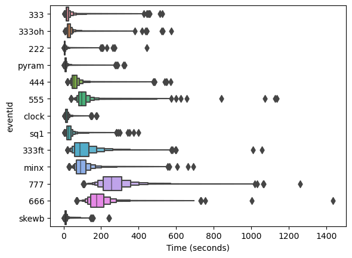

```python
ax = sns.boxenplot(data=df, x='average', y='eventId');
ax.set(xlabel="Time (seconds)")
plt.show()
```

##### Transform data

Our data is heavily skewed to the right, which makes sense if you think about it. Many people start out as novice cubers, but get bored before they improve their times. That would definitely cause a lot more data to the right, i.e. a positive skew. Let's apply a log transformation to our data to make it more centered.

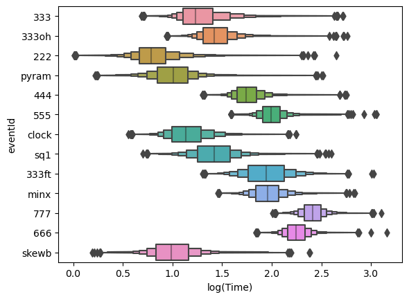

```python
df['average'] = df['average'].apply(lambda x: np.log10(x))
ax = sns.boxenplot(data=df, x='average', y='eventId');
ax.set(xlabel="log(Time)")
plt.show()
```

#### 3ii) Data by country

Let's observe some statistics by country. While the log transformation did help in normalizing the data, they are still quite skewed with a non-insignificant amount of outliers. Our mean would be sensitive to that, so the map below uses the median log(Time) for each country.

We can see that in general, the lowest median 3x3x3 solve times mostly lie in European countries. Additionally, despite their large populations, China and the United States have quite low 3x3x3 solve times.

```python
df3 = df.loc[df.eventId == '333']
med_times = df3.groupby('iso3')['average'].median().reset_index()

country_geo = "https://raw.githubusercontent.com/python-visualization/folium/main/examples/data/world-countries.json"

bins = list(med_times["average"].quantile(np.linspace(0, 1, 6)))

m3 = folium.Map(location=[0, 0], zoom_start=3)

folium.Choropleth(
    geo_data=country_geo,
    name="3x3 log times",
    data=med_times,
    columns=["iso3", "average"],
    key_on='feature.id',
    fill_color="BuPu",
    legend_name="Median 3x3 log(Time) per country",
    bins=bins
).add_to(m3)

folium.LayerControl().add_to(m3)

m3
```

Make this Notebook Trusted to load map: File -> Trust Notebook

[interactive chart not shown]

##### Number of Competitors per country

The map below shows the number of competitors in a country for the data we have. As to be expected, the United States and China have some of the highest populations of WCA competitors. India, Canada, and Brazil also have a significant amount of competitors; compared to other countries.

```python
ccount = df.groupby(["iso3", 'personId']).count().iloc[:, :1]
ccount.reset_index(level=["iso3", "personId"], inplace=True)
ccount['competitionId'] = 1

ccount = ccount.groupby("iso3").count().iloc[:, :1]
ccount.reset_index(level=["iso3"], inplace=True)

m = folium.Map(location=[0, 0], zoom_start=3)

folium.Choropleth(
    geo_data=country_geo,
    name="num_competitors",
    data=ccount,
    columns=["iso3", "personId"],
    key_on='feature.id',
    fill_color="YlGn",
    legend_name="Number of competitors per country",
).add_to(m)

folium.LayerControl().add_to(m)

m
```

Make this Notebook Trusted to load map: File -> Trust Notebook

[interactive chart not shown]

##### Number of World Records by Country

```python
def ct_wr(row):
    ct = 1 if row[0] == "WR" else 0
    ct += 1 if row[1] == "WR" else 0
    return ct

df['num_wr'] = df[['regionalSingleRecord', 'regionalAverageRecord']].apply(axis=1, func=(lambda x: ct_wr(x)))

wrs = df.groupby('iso3')['num_wr'].sum().reset_index()

bins = list(np.linspace(0, 50, 10)) + [100, 217]

mwr = folium.Map(location=[0, 0], zoom_start=3)

folium.Choropleth(
    geo_data=country_geo,
    name="Number of World Records",
    data=wrs,
    columns=["iso3", "num_wr"],
    key_on='feature.id',
    fill_color="BuPu",
    legend_name="Number of World Records",
    bins = bins
).add_to(mwr)

folium.LayerControl().add_to(mwr)

mwr
```

Make this Notebook Trusted to load map: File -> Trust Notebook

[interactive chart not shown]

#### 3iii) Setup for Model

Let's organize the data so that it can be fed into our learning models.

##### Transforming main DataFrame

```python
times = df.groupby(['iso3', 'eventId']).aggregate({'average': 'median', 'num_wr': 'sum'}).reset_index(level=["eventId"])

for country_iso3 in times.index.unique():
    times.loc[pd.Index([country_iso3]), 'num_wr'] = times.loc[pd.Index([country_iso3]), 'num_wr'].sum()

piv = times.pivot(columns="eventId", values="average")
piv = piv.join(times.loc[:, 'num_wr'], how='inner')
piv = piv.groupby(level=0).first()

piv.reset_index(inplace=True)

piv = piv.merge(ccount, how='inner', on='iso3')
piv = piv.rename(columns={'personId': 'num_competitors'})
piv
```

|  | iso3 | 222 | 333 | 333ft | 333oh | 444 | 555 | 666 | 777 | clock | minx | pyram | skewb | sq1 | num_wr | num_competitors |
| --- | --- | --- | --- | --- | --- | --- | --- | --- | --- | --- | --- | --- | --- | --- | --- | --- |
| 0 | -99 | 0.606878 | 1.025706 | NaN | 1.411956 | 1.579493 | 1.885587 | 2.173827 | 2.396287 | NaN | 1.995547 | 0.765669 | 0.981366 | 1.559068 | 0 | 17 |
| 1 | AFG | 0.822168 | 1.328680 | NaN | 1.645324 | 1.952445 | 2.033102 | NaN | NaN | NaN | NaN | 1.234517 | 1.099681 | NaN | 0 | 9 |
| 2 | AGO | NaN | 1.473487 | NaN | NaN | NaN | NaN | NaN | NaN | NaN | NaN | NaN | NaN | NaN | 0 | 1 |
| 3 | ALB | 0.885067 | 1.364644 | NaN | 1.704665 | 1.889750 | 2.158212 | NaN | NaN | NaN | NaN | 1.115611 | 1.274850 | NaN | 0 | 29 |
| 4 | AND | 1.074451 | 1.658392 | NaN | 1.563998 | 1.804753 | 2.085543 | NaN | NaN | NaN | 2.065916 | 1.249191 | 1.295440 | 1.453089 | 0 | 34 |
| ... | ... | ... | ... | ... | ... | ... | ... | ... | ... | ... | ... | ... | ... | ... | ... | ... |
| 144 | WSM | NaN | 1.567849 | NaN | NaN | NaN | NaN | NaN | NaN | NaN | NaN | NaN | NaN | NaN | 0 | 1 |
| 145 | YEM | 0.985305 | 1.727834 | NaN | NaN | NaN | NaN | NaN | NaN | NaN | 2.516681 | NaN | NaN | NaN | 0 | 4 |
| 146 | ZAF | 0.917506 | 1.418218 | 2.143202 | 1.587599 | 1.897325 | 2.127396 | 2.369833 | 2.530123 | 1.139349 | 2.194306 | 1.154120 | 1.119256 | 1.568788 | 0 | 1300 |
| 147 | ZMB | 1.327155 | 1.304491 | NaN | NaN | NaN | NaN | NaN | NaN | NaN | NaN | NaN | NaN | NaN | 0 | 2 |
| 148 | ZWE | 0.761928 | 1.257092 | NaN | 1.596550 | 1.807264 | 2.420055 | NaN | NaN | NaN | 2.294753 | 1.210586 | 1.148669 | NaN | 0 | 6 |

149 rows × 16 columns

##### Scraping data

But in order to make a ranking model, we need training data somehow! Obtaining a ranking from our datasets would be an arduous process involving multiple DataFrame transformation and operations; fortunately the WCA provides country rankings on their website for each event's average and single. Let's scrape that website and rank the countries. As opposed to before, in these rankings we will consider blindfolded events as well to get the most accurate ACTUAL ranking as possible. We will get the ranking of countries for each event's single and average (except Multi-Blind, because those are only done as singles) and assign all the columns a temporary rank 1-n. Then, we will find the mean rank for each country using that temporary rank, sort them by mean rank, and re-rank the rows 1-n. In order to merge with our data, we will also need to convert each country's name to an ISO Alpha-3 code.

```python
#Names of continents and other rows to remove
remove = ['World', 'Europe', 'North America', 'South America', 'Asia', 'Africa', 'Oceania']
base_url = "https://www.worldcubeassociation.org/results/rankings/"

rankdf = pd.DataFrame()

evs = [x for x in a if x not in ['magic', 'mmagic', '333mbo']]

#For each event
for ev in evs:
    if ev == "333mbf":
        url_single = base_url + f"{ev}/single?show=by+region"
        dfs = pd.read_html(url_single)[0]

        dfs = dfs[~dfs['Region'].isin(remove)]
        dfs = dfs.dropna(how='all')
        dfs = dfs.rename(columns={'Region': ev})

        rankdf = pd.concat([rankdf, dfs[ev]], axis=1)
    else:
        #Get region rankings for single and average
        url_single = base_url + f"{ev}/single?show=by+region"
        url_avg = base_url + f"{ev}/average?show=by+region"

        dfs = pd.read_html(url_single)[0]
        dfa = pd.read_html(url_avg)[0]

        dfs = dfs[~dfs['Region'].isin(remove)]
        dfs = dfs.dropna(how='all')
        dfs = dfs.rename(columns={'Region': ev+'_s'})

        dfa = dfa[~dfa['Region'].isin(remove)]
        dfa = dfa.dropna(how='all')
        dfa = dfa.rename(columns={'Region': ev+'_a'})

        if rankdf.empty:
            rankdf = pd.concat([dfs[ev+'_s'], dfa[ev+'_a']], axis=1)
        else:
            rankdf = pd.concat([rankdf, dfs[ev+'_s'], dfa[ev+'_a']], axis=1)


#Some columns have leading NaNs, so push columns upwards if they do
for col in rankdf:
    while pd.isna(rankdf[col].iat[0]):
        rankdf[col] = rankdf[col].shift(-1)

#Now each country is ordered correctly for each event, assign a temp rank to aggregate on (1-n)
rankdf['rank'] = np.arange(1, 155)

#Define every ranking category
cols = list(rankdf.columns)
cols.remove('rank')
cols.remove('333_s')

#Since 3x3 Single has the most countries for its' data, we will start rank data with that
rdata = rankdf.pivot_table(values='rank', columns='333_s', aggfunc='mean').T.reset_index()
rdata = rdata.rename(columns={'333_s': 'country'})

#For each ranking category, create a column of ranks for each country and add it to rdata
for c in cols:
    d = rankdf.pivot_table(values='rank', columns=c, aggfunc='first').T.reset_index()
    rdata = rdata.merge(d, how='left', left_on='country', right_on=c, suffixes=(None, c)).fillna(150)
    rdata = rdata.drop(columns=c)

#Compute mean rank across row (for each country)
rdata['overall_rank'] = rdata.iloc[:, 1:].mean(axis=1)

#Drop extraneous rows, sort by rank, and rerank from 1-n (because previous mean operation produces floats)
rdata = rdata.drop(labels=['rank'] + ["rank"+c for c in cols], axis=1)
rdata = rdata.sort_values('overall_rank')
rdata['overall_rank'] = np.arange(1, 151)

#Define iso-3 conversion
def to_iso32(c):
    try:
        x = pycountry.countries.search_fuzzy(c)[0].alpha_3
        return x
    except Exception:
        return "INVALID"

#Perform conversion
rdata['iso3'] = rdata['country'].apply(lambda x: to_iso32(x))

#Incorrect/invalid values; fill in manually
rdata.loc[rdata.country == "Macau", 'iso3'] = "MAC"
rdata.loc[rdata.country == "CÃ´te d'Ivoire", 'iso3'] = "CIV"
rdata.loc[rdata.country == "Democratic Republic of the Congo", 'iso3'] = "COD"
rdata.loc[rdata.country == "Republic of Korea", 'iso3'] = "KOR"
rdata.loc[rdata.country == "Kosovo", 'iso3'] = "-99"
rdata
```

|  | country | overall_rank | iso3 |
| --- | --- | --- | --- |
| 142 | United States | 1 | USA |
| 25 | China | 2 | CHN |
| 105 | Poland | 3 | POL |
| 7 | Australia | 4 | AUS |
| 44 | Germany | 5 | DEU |
| ... | ... | ... | ... |
| 39 | Eritrea | 146 | ERI |
| 84 | Monaco | 147 | MCO |
| 138 | Uganda | 148 | UGA |
| 33 | Democratic Republic of the Congo | 149 | COD |
| 78 | Malawi | 150 | MWI |

150 rows × 3 columns

Now we can merge our scraped data with our times. Since we have some missing values, let's encode them with very high or 0 values accordingly so that our model can distinguish them.

```python
#Merge scraped data with times
data = rdata.merge(piv, how='outer', on="iso3").sort_values('overall_rank')

#fill NaN accordingly
data.iloc[:, 3:16] = data.iloc[:, 3:16].fillna(99999)
data['num_wr'] = data['num_wr'].fillna(0)

#Drop rows with invalid num_competitors (every valid row should have one)
data = data.dropna(how='any')
data
```

|  | country | overall_rank | iso3 | 222 | 333 | 333ft | 333oh | 444 | 555 | 666 | 777 | clock | minx | pyram | skewb | sq1 | num_wr | num_competitors |
| --- | --- | --- | --- | --- | --- | --- | --- | --- | --- | --- | --- | --- | --- | --- | --- | --- | --- | --- |
| 0 | United States | 1 | USA | 0.783189 | 1.223496 | 1.912461 | 1.411788 | 1.736715 | 1.979867 | 2.225891 | 2.386998 | 1.095866 | 1.931941 | 1.023664 | 0.994757 | 1.357172 | 217.0 | 33488.0 |
| 1 | China | 2 | CHN | 0.783189 | 1.218798 | 1.843793 | 1.379849 | 1.712060 | 1.972249 | 2.228169 | 2.387443 | 1.113442 | 1.931966 | 0.982271 | 0.946452 | 1.404663 | 45.0 | 22381.0 |
| 2 | Poland | 3 | POL | 0.711807 | 1.171726 | 1.851197 | 1.364551 | 1.696924 | 1.969998 | 2.215981 | 2.383402 | 1.053846 | 1.883661 | 0.877371 | 0.877371 | 1.325618 | 89.0 | 4185.0 |
| 3 | Australia | 4 | AUS | 0.802089 | 1.265525 | 1.833384 | 1.414472 | 1.743588 | 1.988960 | 2.244722 | 2.414773 | 1.120738 | 1.941114 | 1.059942 | 1.038024 | 1.369123 | 125.0 | 6380.0 |
| 4 | Germany | 5 | DEU | 0.753200 | 1.177536 | 1.912965 | 1.408240 | 1.731790 | 1.991004 | 2.281726 | 2.442637 | 1.055760 | 1.950170 | 0.983626 | 0.973590 | 1.442009 | 34.0 | 2473.0 |
| ... | ... | ... | ... | ... | ... | ... | ... | ... | ... | ... | ... | ... | ... | ... | ... | ... | ... | ... |
| 144 | Senegal | 145 | SEN | 99999.000000 | 1.781579 | 99999.000000 | 99999.000000 | 99999.000000 | 99999.000000 | 99999.000000 | 99999.000000 | 99999.000000 | 99999.000000 | 99999.000000 | 99999.000000 | 99999.000000 | 0.0 | 1.0 |
| 145 | Eritrea | 146 | ERI | 99999.000000 | 1.691825 | 99999.000000 | 99999.000000 | 99999.000000 | 99999.000000 | 99999.000000 | 99999.000000 | 99999.000000 | 99999.000000 | 99999.000000 | 99999.000000 | 99999.000000 | 0.0 | 2.0 |
| 146 | Monaco | 147 | MCO | 99999.000000 | 1.832573 | 99999.000000 | 99999.000000 | 99999.000000 | 99999.000000 | 99999.000000 | 99999.000000 | 99999.000000 | 99999.000000 | 99999.000000 | 99999.000000 | 99999.000000 | 0.0 | 1.0 |
| 147 | Uganda | 148 | UGA | 99999.000000 | 1.853020 | 99999.000000 | 99999.000000 | 99999.000000 | 99999.000000 | 99999.000000 | 99999.000000 | 99999.000000 | 99999.000000 | 99999.000000 | 99999.000000 | 99999.000000 | 0.0 | 1.0 |
| 149 | Malawi | 150 | MWI | 99999.000000 | 2.065131 | 99999.000000 | 99999.000000 | 99999.000000 | 99999.000000 | 99999.000000 | 99999.000000 | 99999.000000 | 99999.000000 | 99999.000000 | 99999.000000 | 99999.000000 | 0.0 | 1.0 |

149 rows × 18 columns

## 4) Hypothesis Testing

#### 4i) Random Forests

##### Null Hypothesis:

The model cannot accurately rank the data. To be more specific, there is no correlation between the actual rankings and predicted rankings outputted by the model.

##### Alternative Hypothesis:

The model can accurately rank the data. In other words, there is a correlation between the actual rankings and predicted rankings outputted by the model.

```
Correlation: 0.9026570354876895
p-value: 4.1298053201787615e-276
```

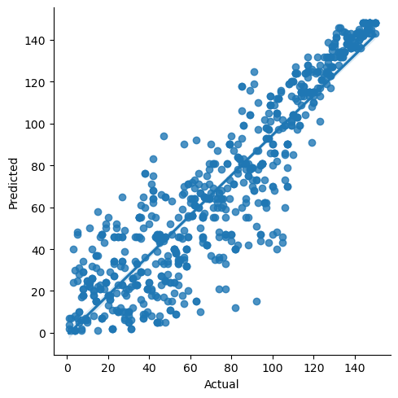

```python
# Split the data into training and test sets
X = data.drop(columns=['country', 'overall_rank', 'iso3'])
y = data['overall_rank']

rs = ShuffleSplit(n_splits=10, test_size=0.5)

actual = []
predicted = []

for i, (train_index, test_index) in enumerate(rs.split(X)):
    X_train, X_test = X.iloc[train_index], X.iloc[test_index]
    y_train, y_test = y.iloc[train_index], y.iloc[test_index]

    rfc = RandomForestClassifier().fit(X_train, y_train)
    y_out = rfc.predict(X_test)

    actual.extend(list(y_test))
    predicted.extend(list(y_out))


vals = pd.DataFrame(list(zip(actual, predicted)), columns =['Actual', 'Predicted'])
sns.lmplot(vals, x='Actual', y='Predicted')

res = stats.spearmanr(actual, predicted)
print("Correlation:", res.correlation)
print("p-value:", res.pvalue)
```

#### 4ii) Histogram Gradient Boosting

As we can see, the data has quite a strong correlation. Since our p-value is very small (may not be exactly 0, but very close to 0.00), we've already successfully rejected the null hypothesis, proving that our Random Forest Classifier model can accurately rank data! But upon examining the scatterplot, it seems like some of the middle values are not predicted very well. Many points of data seem clumped up towards either end of the line, and the rest of the points are rather sparsely distributed. This may indicate the model can predict extreme values more accurately, but it's unfair to most countries.

Let's try another model to see if it can predict middle rankings more accurately. The HistGradientBoostingClassifier from the 'sklearn' library is supposed to handle missing values especially well, so we will proceed with that.

```
Correlation: 0.9545126712294578
p-value: 0.0
```

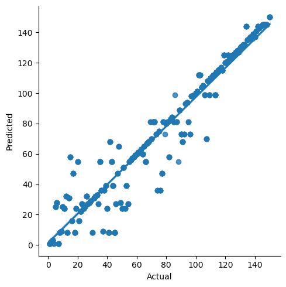

```python
rs = ShuffleSplit(n_splits=10, test_size=0.5)

actual = []
predicted = []

for i, (train_index, test_index) in enumerate(rs.split(X)):
    X_train, X_test = X.iloc[train_index], X.iloc[test_index]
    y_train, y_test = y.iloc[train_index], y.iloc[test_index]

    hgb = HistGradientBoostingClassifier().fit(X_train, y_train)
    y_out = rfc.predict(X_test)

    actual.extend(list(y_test))
    predicted.extend(list(y_out))

vals = pd.DataFrame(list(zip(actual, predicted)), columns =['Actual', 'Predicted'])
sns.lmplot(vals, x='Actual', y='Predicted')

res = stats.spearmanr(actual, predicted)
print("Correlation:", res.correlation)
print("p-value:", res.pvalue)
```